# Лекция 3. DAG: язык причинных графов

Блок 0. Данные и язык причинности

Карен Аванесян

Каузальный анализ в R на данных RLMS-HSE

# Зачем

## Вопрос, на который не отвечают данные

На прошлой лекции курильщики были заняты «так же», а внутри каждого пола — «реже». Какая цифра правильная?

Данные не могут решить, что включать в регрессию. Это решает **структура причин** — то, что мы *предполагаем* о мире. DAG — способ записать эти предположения так, чтобы из них можно было **вывести**, за что контролировать, а за что нельзя.

- DAG = directed acyclic graph: стрелки = «влияет на», без циклов
- Нарисовали граф → алгоритм выдаёт **набор корректировки** (adjustment set)
- Один и тот же контроль может убрать смещение в одном графе и создать его в другом

## План занятия

1. Три строительных блока: цепь, развилка, коллайдер
2. Backdoor-критерий: что контролировать
3. Плохие контроли: медиаторы, коллайдеры, потомки воздействия
4. `dagitty` и `ggdag`: граф → набор корректировки
5. Проверяемые следствия графа на RLMS

# Идея

## Три структуры, из которых состоит всё

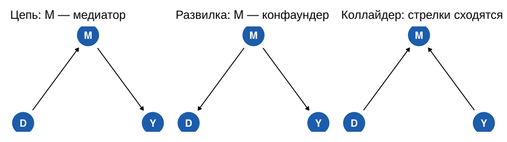

цепь D → M → Y

Без контроля связь D и Y **есть** (причинная). Если условиться на M — **исчезает**: мы «перекрыли» механизм

развилка D ← M → Y

Без контроля связь D и Y **есть** (ложная). Если условиться на M — **исчезает**: конфаундер убран

коллайдер D → M ← Y

Без контроля связи D и Y **нет**. Если условиться на M — **появляется**: ложная связь создана

## Коллайдер: как условие создаёт связь

Талант и внешность не связаны. Но в кино попадают те, у кого есть хотя бы одно. Среди актёров талантливые — в среднем менее красивы:

```r
set.seed(3)
actors <- tibble(talent = rnorm(3000), looks = rnorm(3000),
                 star = talent + looks + rnorm(3000, 0, 0.5) > 1.5)
bind_rows(actors |> summarise(выборка = "все", корреляция = cor(talent, looks)),
          actors |> filter(star) |> summarise(выборка = "только звёзды", корреляция = cor(talent, looks)))
```

| выборка | корреляция |
| --- | --- |
| все | -0.003 |
| только звёзды | -0.520 |

Коллайдер — главный источник «неочевидных» ошибок: отбор в выборку (только занятые, только ответившие, только выжившие) — это условие на коллайдер.

## Backdoor-критерий

Набор $Z$ достаточен для оценки эффекта $D \to Y$, если:

1. $Z$ **блокирует все backdoor-пути** — пути из $D$ в $Y$, начинающиеся стрелкой *в* $D$
2. $Z$ **не содержит потомков** $D$

Путь заблокирован, если на нём есть **конфаундер или медиатор, на который мы условились**, или **коллайдер, на который мы не условились** (и ни на одного его потомка).

Всё, что делает регрессия с контролями, мэтчинг и взвешивание (лекции 4–6) — реализуют backdoor-корректировку. Разница только в технике, допущение одно.

## Четыре вида плохих контролей

Что добавили — и что получили (нажмите на карточку):

медиатор

### Профессию

…в регрессию зарплаты на образование

**D → M → Y:** «прямой» эффект вместо полного; плюс открыли коллайдер, если у M есть свои причины

коллайдер

### Только занятых

…при оценке эффекта здоровья на зарплату

**Здоровье → занятость ← мотивация → зарплата:** ложная связь

потомок D

### Зарплату *после* программы

…как контроль для эффекта на часы работы

**Потомок D:** часть эффекта «съедена»

M-bias

### Переменную, измеренную до D

…но являющуюся коллайдером скрытых причин

**M-bias:** открыли путь, которого не было

Правило большого пальца: контроль должен быть **причиной D или Y, измеренной до D**, и не быть следствием D. Остальное — думать по графу.

## Table 2 fallacy

В регрессии $\log w = \beta_1 \text{educ} + \beta_2 \text{female} + \beta_3 \text{age} + \ldots$ только $\beta_1$ — эффект, для которого подобран набор корректировки.

- $\beta_2$ — **не** «эффект пола»: для него нужен свой набор, и образование для него — медиатор
- $\beta_3$ — не «эффект возраста»
- Westreich & Greenland (2013): «Table 2» с интерпретацией всех коэффициентов — систематическая ошибка эпидемиологии и социологии

Одна регрессия — один причинный коэффициент. Остальные — вспомогательные.

## Чего DAG не делает

- Не говорит о **величине** и форме эффектов — только о структуре
- Не берётся из данных: стрелки — это **предположения из теории**; данные могут лишь опровергнуть граф (через условные независимости, которых в данных нет), но не подтвердить
- Не решает проблему **неизмеренных** конфаундеров — только показывает, где они. Для них нужны другие дизайны: панель (лекция 7), естественные эксперименты (10–13)
- Паттерны IV и front-door — тоже графы: инструмент $Z \to D \to Y$ без пути $Z \to Y$ в обход $D$

# Код

## Граф «образование → зарплата»

- Граф
- Код

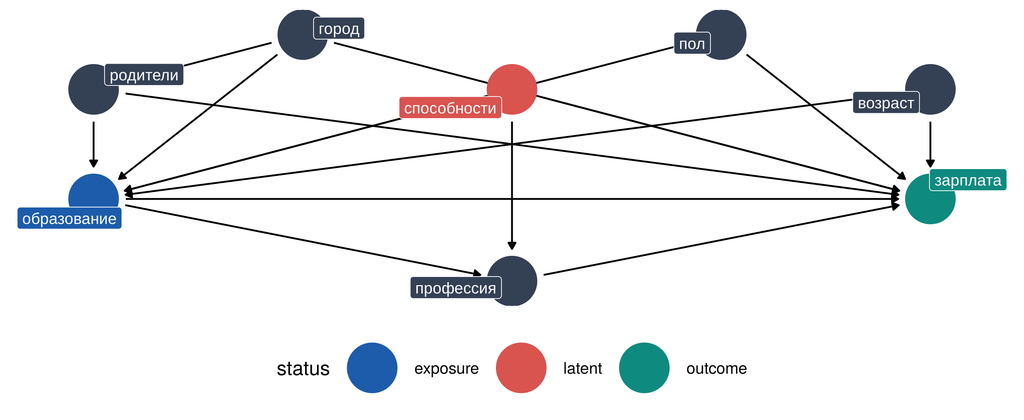

```r
make_edu_dag <- function(latent = "ability") dagify(
  wage  ~ educ + ability + age + female + urban + parents + occup,
  educ  ~ ability + parents + urban + female + age,
  occup ~ educ + ability,
  parents ~ urban,
  exposure = "educ", outcome = "wage", latent = latent,
  labels = c(wage = "зарплата", educ = "образование", ability = "способности",
             age = "возраст", female = "пол", urban = "город", parents = "родители",
             occup = "профессия"),
  coords = list(x = c(educ = 0, wage = 4, ability = 2, parents = 0, urban = 1, female = 3,
                      age = 4, occup = 2),
                y = c(educ = 0, wage = 0, ability = 2, parents = 2, urban = 3, female = 3,
                      age = 2, occup = -1.5)))
edu_dag <- make_edu_dag()
ggdag_status(edu_dag, use_labels = "label", text = FALSE, node_size = 16) +
  theme_dag_course() + theme(legend.position = "bottom")
```

## Что контролировать: `adjustmentSets()`

```r
sets <- adjustmentSets(edu_dag, exposure = "educ", outcome = "wage", type = "minimal")
length(sets)                                     # сколько наборов найдено
```

```
[1] 0
```

- `dagitty` перебирает пути и находит минимальные наборы, блокирующие все backdoor-пути
- Способности помечены как **ненаблюдаемые** (`latent`), поэтому набор из наблюдаемых переменных не существует — алгоритм честно отвечает «ноль наборов»
- Это и есть формальная версия вывода лекции 1: без способностей (или дизайна, который их обходит) полный эффект образования по этому графу не идентифицируется

## Если бы способности были измерены

```r
edu_dag2 <- make_edu_dag(latent = NULL)          # способности наблюдаемы
adjustmentSets(edu_dag2, exposure = "educ", outcome = "wage", type = "minimal")
```

```
{ ability, age, female, parents, urban }
```

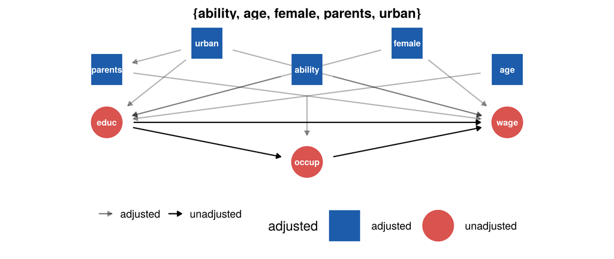

Профессия (`occup`) в набор не входит — она **после** образования.

## Как читать вывод `adjustmentSets()`

- Вывод R
- С пояснениями

```r
adjustmentSets(edu_dag)                              # способности ненаблюдаемы
adjustmentSets(edu_dag2)                             # способности измерены
## { ability, age, female, parents, urban }
adjustmentSets(edu_dag2, effect = "direct")          # прямой эффект, без медиатора
## { ability, age, female, occup, parents, urban }
adjustmentSets(dagitty("dag{ x -> y }"), exposure = "x", outcome = "y")
##  {}
```

1 · `{ a, b, c }`

Одна строка — **один** достаточный набор: контролировать нужно все переменные в скобках вместе

2 · несколько строк

Альтернативные наборы: любой из них закрывает все backdoor-пути. Берите тот, что лучше измерен в данных

3 · пустой вывод

Не напечатано **ничего** — набора нет: эффект по этому графу через контроль не идентифицируется (здесь мешают `latent`-способности)

4 · `{}`

Пустые скобки — противоположный случай: набор есть, и он пуст. Контролировать ничего не нужно. Не путайте с п. 3

5 · аргументы

`effect = "total"` (умолчание) или `"direct"` — для прямого эффекта в набор входит медиатор `occup`. `type`: `"minimal"` (умолчание), `"canonical"`, `"all"`

6 · сигналы беды

Набора нет, а регрессию всё равно запускают; в наборе переменная, измеренная **после** воздействия (проверьте стрелки); набор требует того, чего нет в данных

## Профессия — медиатор, а не контроль

```r
work <- adults |> filter(employed == 1, age >= 25, !is.na(log_wage), !is.na(higher_ed))
m_total  <- feols(log_wage ~ higher_ed + female + age + I(age^2) + urban | year,
                  data = work, cluster = ~psu)
m_direct <- feols(log_wage ~ higher_ed + female + age + I(age^2) + urban + occup_group | year,
                  data = work, cluster = ~psu)
etable(m_total, m_direct, keep = "higher_ed", depvar = FALSE, drop.section = "fixef",
       fitstat = ~ n, headers = c("без профессии", "+ профессия"))
```

|  | m_total | m_direct |
| --- | --- | --- |
|  | без профессии | + профессия |
| higher_ed | 0.337*** (0.024) | 0.221*** (0.018) |
| _______________ | ________________ | ________________ |
| S.E.: Clustered | by: psu | by: psu |
| Observations | 155,582 | 155,329 |

С профессией коэффициент падает на треть: мы выключили главный механизм (диплом → должность → зарплата). Для **полного** эффекта профессию включать нельзя; для **прямого** — можно, но тогда сама профессия должна быть «как случайная» при данном образовании.

## Коллайдер в RLMS: условие на занятость

Хотим эффект **здоровья** на зарплату. Зарплата есть только у занятых — а занятость зависит и от здоровья, и от многого другого:

- Граф
- Код

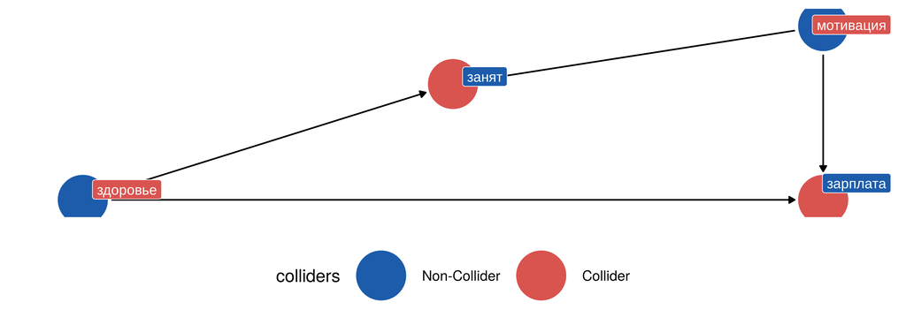

```r
sel_dag <- dagify(wage ~ health + motiv, employed ~ health + motiv,
                  exposure = "health", outcome = "wage", latent = "motiv",
                  labels = c(wage = "зарплата", health = "здоровье", motiv = "мотивация",
                             employed = "занят"),
                  coords = list(x = c(health = 0, wage = 2, motiv = 2, employed = 1),
                                y = c(health = 0, wage = 0, motiv = 1.5, employed = 1)))
ggdag_collider(sel_dag, use_labels = "label", text = FALSE, node_size = 18,
               label_size = 4) + theme_dag_course() + theme(legend.position = "bottom")
```

## Коллайдер в RLMS: что получается в числах

Внутри занятых здоровье и (ненаблюдаемая) мотивация связаны отрицательно — больные работают, только если очень мотивированы. Симулируем ровно этот мир:

```r
set.seed(11)
sim <- tibble(health = rnorm(20000), motiv = rnorm(20000)) |>
  mutate(employed = health + motiv + rnorm(n()) > 0.3,
         wage = 10 + 0.10 * health + 0.30 * motiv + rnorm(n(), 0, 0.5))   # эффект = 0.10
c(`все`         = coef(lm(wage ~ health, sim))["health"],
  `только занятые` = coef(lm(wage ~ health, sim |> filter(employed)))["health"])
```

```
           все.health только занятые.health
               0.1012                0.0087
```

- Среди занятых эффект здоровья **занижен**: отбор создал отрицательную связь здоровья с мотивацией
- В RLMS мотивацию не измерить — значит, вопрос о зарплате всегда задаётся **вместе** с вопросом о занятости (лекция 17: границы, модели отбора)

## Проверяемые следствия графа

Граф утверждает условные независимости. Их можно проверить — и опровергнуть граф:

```r
small_dag <- dagify(wage ~ educ + female + age + urban, educ ~ female + urban + age,
                    smokes ~ female + age, exposure = "educ", outcome = "wage")
impliedConditionalIndependencies(small_dag)
```

```
age _||_ feml
age _||_ urbn
educ _||_ smks | age, feml
feml _||_ urbn
smks _||_ urbn
smks _||_ wage | age, feml
```

## Проверяем следствия на RLMS 2019

```r
cs <- work |> filter(year == 2019) |>
  select(wage = log_wage, educ = years_educ, female, age, urban, smokes) |> drop_na()
lt <- localTests(small_dag, data = cs, type = "cis", abbreviate.names = FALSE)
round(lt, 3)
```

|  | estimate | p.value | 2.5% | 97.5% |
| --- | --- | --- | --- | --- |
| age *\|\|* female | 0.049 | 0.000 | 0.025 | 0.073 |
| age *\|\|* urban | -0.047 | 0.000 | -0.071 | -0.023 |
| educ *\|\|* smokes \| age, female | -0.232 | 0.000 | -0.255 | -0.209 |
| female *\|\|* urban | -0.003 | 0.779 | -0.027 | 0.021 |
| smokes *\|\|* urban | 0.008 | 0.539 | -0.016 | 0.031 |
| smokes *\|\|* wage \| age, female | -0.028 | 0.024 | -0.051 | -0.004 |

`estimate` — частная корреляция, которая по графу должна быть нулём.

## Как читать вывод `localTests()`

- Вывод R
- С пояснениями

|  | estimate | p.value | 2.5% | 97.5% |
| --- | --- | --- | --- | --- |
| age *\|\|* female | 0.049 | 0.000 | 0.025 | 0.073 |
| age *\|\|* urban | -0.047 | 0.000 | -0.071 | -0.023 |
| educ *\|\|* smokes \| age, female | -0.232 | 0.000 | -0.255 | -0.209 |
| female *\|\|* urban | -0.003 | 0.779 | -0.027 | 0.021 |
| smokes *\|\|* urban | 0.008 | 0.539 | -0.016 | 0.031 |
| smokes *\|\|* wage \| age, female | -0.028 | 0.024 | -0.051 | -0.004 |

1 · строка

`A _||_ B | C` — следствие графа: «A и B независимы при данных C». Тот же список печатает `impliedConditionalIndependencies()` (там имена сокращены: `smks`, `feml`)

2 · estimate

При `type = "cis"` — **частная корреляция** A и B после линейного учёта C. По графу должна быть 0. Это размер нарушения, шкала от −1 до 1

3 · p.value

Тест $H_0$: корреляция = 0. Малое p — следствие отвергнуто: неверен граф **или** линейность (для категорий — `"cis.chisq"`, `"cis.pillai"`)

4 · 2.5 % и 97.5 %

95 %-й интервал для корреляции. Смотрите на **величину**: при $n$ = 6 699 «значимыми» становятся и корреляции порядка 0.03

5 · что не напечатано

N в выводе нет: проверьте `nrow(data)`. Пропуски убирайте заранее — как `drop_na()` в коде выше

6 · сигналы беды

Крупная |estimate| (здесь `educ`–`smokes`); отвергнуто много следствий сразу. И обратное: «не отвергнуто» ≠ «граф верен»

## Что тесты говорят о графе

- `educ ⟂ smokes | age, female`: по графу образование и курение при данных возрасте и поле не связаны. Частная корреляция -0.23 → граф **неверен**: нужна стрелка `educ → smokes` (или общая причина)
- `smokes ⟂ wage | age, female`: отвергается слабо (-0.03). После добавления стрелки `educ → smokes` это следствие исчезнет: образование станет конфаундером связи курения и зарплаты
- `female ⟂ urban`, `smokes ⟂ urban`: не отвергнуты — но это **не доказывает** граф: мощность теста и неизмеренные переменные остаются
- Слабые, но «значимые» нарушения (`age ⟂ female`, 0.05) при $n$ = 6 699 — повод подумать, а не переделывать граф

Рисуйте граф **до** анализа, проверяйте следствия, исправляйте, записывайте, что изменили. Это и есть «прозрачные допущения».

## M-bias: вред от контроля «до»

```r
set.seed(4)
mb <- tibble(u1 = rnorm(20000), u2 = rnorm(20000)) |>
  mutate(m = u1 + u2 + rnorm(n()),                 # коллайдер скрытых причин, измерен до D
         d = u1 + rnorm(n()) > 0,
         y = 0.5 * u2 + rnorm(n()))                 # истинный эффект D на Y = 0
c(`без контроля` = coef(lm(y ~ d, mb))["dTRUE"],
  `с контролем m` = coef(lm(y ~ d + m, mb))["dTRUE"])
```

```
 без контроля.dTRUE с контролем m.dTRUE
             0.0147             -0.1907
```

- Без контроля смещения нет: единственный путь от D к Y через `m` закрыт коллайдером
- Контроль за «предшествующей» переменной открыл путь `d ← u1 → m ← u2 → y`
- На практике M-bias обычно мал, но правило «контролируй всё, что измерено до воздействия» — не абсолютно

# Как ошибаются

## Шесть ошибок с контролями

1. **Кухонная раковина**: «включили всё, что было в данных» — медиаторы и коллайдеры в том числе
2. **Контроль за следствием воздействия**: профессия, доход, здоровье *после* программы
3. **Отбор по исходу**: анализ только тех, кто «успешен», «занят», «ответил на все вопросы»
4. **Интерпретация всех коэффициентов** (Table 2 fallacy)
5. **Граф, подогнанный под результат**: стрелки меняются, пока коэффициент не станет «правильным»
6. **Граф без неизмеренных узлов**: если способности не нарисованы, они не исчезли

## Чек-лист перед выбором контролей

- Граф нарисован **до** оценок, с латентными узлами
- Воздействие и исход отмечены; для них найден набор корректировки
- Ни один контроль не является потомком воздействия
- Выборка не отобрана по переменной, лежащей на пути D → Y или являющейся общим следствием
- Проверены хотя бы 2–3 следствия графа на данных
- Интерпретируется **только** коэффициент при воздействии

# Мини-задача

## Задание к следующему занятию

1. Нарисуйте DAG для вопроса «курение → зарплата» с не менее чем 7 узлами, включая хотя бы один латентный и один коллайдер. Получите наборы корректировки в `dagitty`
2. Найдите в своём графе переменную, контроль за которой **создаёт** смещение. Покажите это симуляцией на 10 000 наблюдений
3. Проверьте три следствия своего графа на RLMS 2019 с помощью `localTests()`. Какие стрелки пришлось добавить?
4. Объясните в трёх предложениях, почему «эффект пола» из регрессии зарплаты на образование — не эффект пола

# Литература

## Что прочитать

- Pearl J., Glymour M., Jewell N. (2016). *Causal Inference in Statistics: A Primer* — гл. 2–3
- Cunningham S. *The Mixtape*, гл. 3 «Directed Acyclic Graphs» — коллайдеры и backdoor без формул
- Huntington-Klein N. *The Effect*, гл. 6–8 — рисование графов, пути, «хорошие и плохие контроли»
- Cinelli C., Forney A., Pearl J. (2022). A Crash Course in Good and Bad Controls. *Sociological Methods & Research*
- Westreich D., Greenland S. (2013). The Table 2 Fallacy. *American Journal of Epidemiology*
- Пакеты: [`dagitty`](https://dagitty.net/) (есть и браузерный редактор), [`ggdag`](https://r-causal.github.io/ggdag/)

Каузальный анализ в R · RLMS-HSE · К. Аванесян

← К программе курса